# Lab assignment: dogs VS cats

### Predicciones Falladas por el Modelo Intermedio

```
El modelo Intermediate Model ha fallado en 529 casos, es decir un porcentaje de 0.1058
```

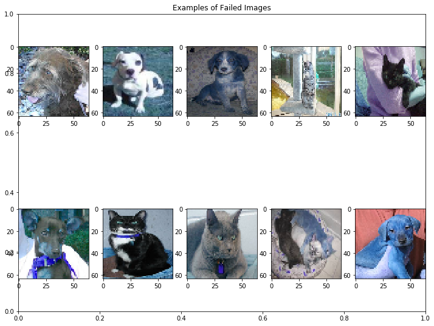

```python
get_failed_predictions(y_true=y_test, preds=predictions2, nombre='Intermediate Model')
```

### Predicciones Fallidas del Modelo Más Profundo

```
El modelo Deep Model ha fallado en 540 casos, es decir un porcentaje de 0.108
```

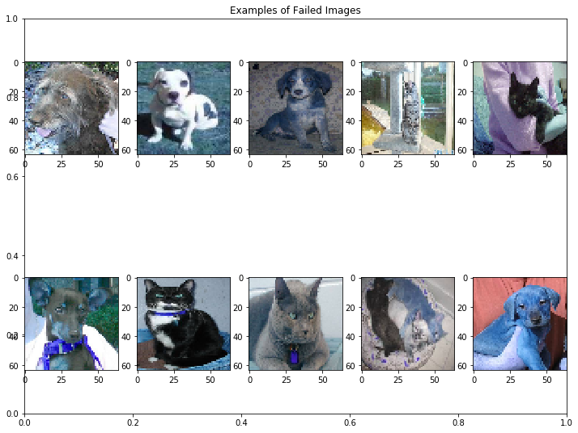

```python
get_failed_predictions(y_true=y_test, preds=predsDeep, nombre='Deep Model')
```

Write a small report summarizing the network choices you have tried, what worked and what didn't. What have you learned from this experience?

## REFLEXIONES Y CONCLUSIÓN.

Hay algunas conclusiones que podemos obtener de estos experimentos que hemos llevado a cabo. En primer lugar, debe decirse que no todos los resultados que se han ido obteniendo se han presentado en este report, pues muchos de ellos fueron modelos inútiles que no eran capaces de distinguir entre perros y gatos. Nos ha llamado la atención que el generador de imágenes de keras no nos ha ayudado en exceso a mejorar las predicciones, y con el modelo intermedio de hecho no ha servido prácticamente de nada. Otra conclusión importante es que para llevar a cabo proyectos de deep learning de una forma un poco más seria es importante tener a nuestra disposición un hardware suficientemente potente, pues entrenar estos modelos con las GPUs de Google Colab pero con las limitaciones de RAM que tiene nuestro ordenador no es demasiado eficiente. Un efecto directo de esto es el lastre en la búsqueda de hiperparámetros, pues para hacer esto el cache en memoria sube mucho y nuestro ordenador no es capaz de hacer más de 4 iteraciones sin morirse. Otras consideraciones antes de entrar a valorar los diferentes métodos utilizados es que, como podemos ver en los gráficos del primer modelo, es muy fácil que los modelos de deep learning sobreajusten, como podemos ver por la divergencia en el entrenamiento entre el loss del train y de validation. Por este motivo es importante introducirle unas tasas de dropout altas y aplicarlas sobre muchas de las capas de la red. De esta forma propiciamos la colaboración de las neuronas.

Respecto a la adaptación de modelos preentrenados, hay dos formas de hacerlo. La primera, que es la que se recomienda o la que hemos visto en la red que se utiliza para adaptar estas redes a problemas nuevos es predecir con la red preentrenada sobre las imágenes y esa predicción utilizarla como features de nuestro problema de clasificación. En este caso lo que mejor ha funcionado es implementarlo directamnete sobre las imágenes transformadas, una posible explicación de esto es que nuestra muestra era insuficiente para lo grandes que son estos modelos y por lo tanto el modelo no conseguía converger, cosa que sí hace cuando le presentamos batches de muchas imágenes transformadas. Estos modelos, en conjunto con el resto de la arquitectura de la red que les aplicamos nosotros a continuación de su arquitectura, no son capaces de mejorar a nuestro modelo intermedio, que alcanza entre un 88% y un 91% de accuracy.

Además de todas las pruebas que se proponían en la práctica, hemos probado algunas otras. Una de las que mejor resultados ha dado ha sido el adaptador del learning rate, pues cuando los modelos parece que no pueden bajar más el error de validación, ayuda a que estos terminen de afinar la puntería. El BatchNormalization() produce una mayor velocidad en el entrenamiento, aunque en modelos "pequeños" como los que hemos probado aquí las diferencias no son significativas. Por último, el zeropadding que añade 0s en los bordes, no añade ningún efecto significativo sobre la predicción; no mejora el modelo. Hemos indagado con las posibilidades que nos otorga el paquete keras_explain, definiendo una función que nos permite ver qué ven los modelos cuando analizan una imagen. De esta forma entendemos mejor por qué funcionan o no funcionan los modelos de Deep Learning para clasificación de imágenes. Vemos que los modelos hacen distinciones de color y de formas quedándose con partes concretas de la imagen para decidir.

Una contrariedad de trabajar con imágenes en baja resolución como hemos hecho nosotros es que los modelos no pueden afinar tanto la puntería, además de que no podemos utilizar todos los modelos preentrenados de Keras Applications, pues muchos de ellos necesitan de imágenes mínimo 75x75. Incluso nuestro ojo tiene dificultades en algunas imágenes a esta baja resolución para reconocer los objetos que aparecen en la imagen, como vimos antes. No podemos esperar por tanto que los modelos acierten absolutamente todas las imágenes, y menos aun si son 64x64, pues al tener menos píxeles a su disposición no pueden identificar correctamente rasgos como las orejas o los ojos que son algunos de los rasgos que mejor distinguen los gatos de los perros. Sin embargo, los modelos sí son capaces de quedarse con rasgos como el morro de los perros, como vemos en el ejemplo de arriba (la foto amarilla y morada de los gráficos 2 y 4 del apartado "Qué ven los modelos de deep learning?").

Después de muchas pruebas que hemos hecho, hemos visto un patrón común, y es que el tipo de arquitectura que suele funcionar bastante bien es poner bloques de: capa convolucional --> BatchNormalization --> capa MaxPooling --> Dropout, después capa Flatten, de nuevo dropout, y luego bloques de Dense y Dropout uno detrás de otro, con este dropout más alto que el que utilizamos en los otros bloques. Este tipo de arquitectura, más grande o más pequeña y con algunos parámetros variables, es lo que mejor ha resultado para distinguir entre perros y gatos.